# glow

[figure not shown]

*A package for making glow-y plots*

The `glow` package is a framework for creating plots with glowing points as an alternative way of plotting large point clouds.

## Gallery

Diamond Prices

Glow-y Spiral

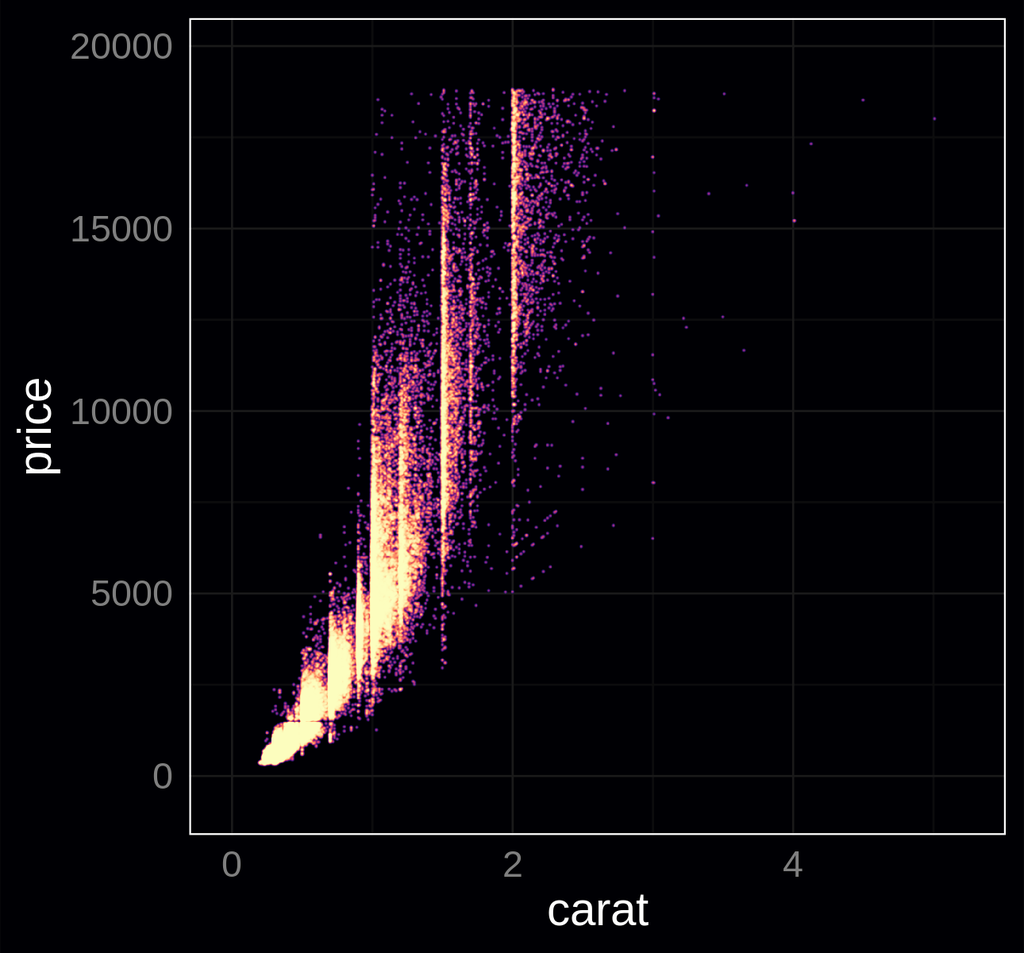

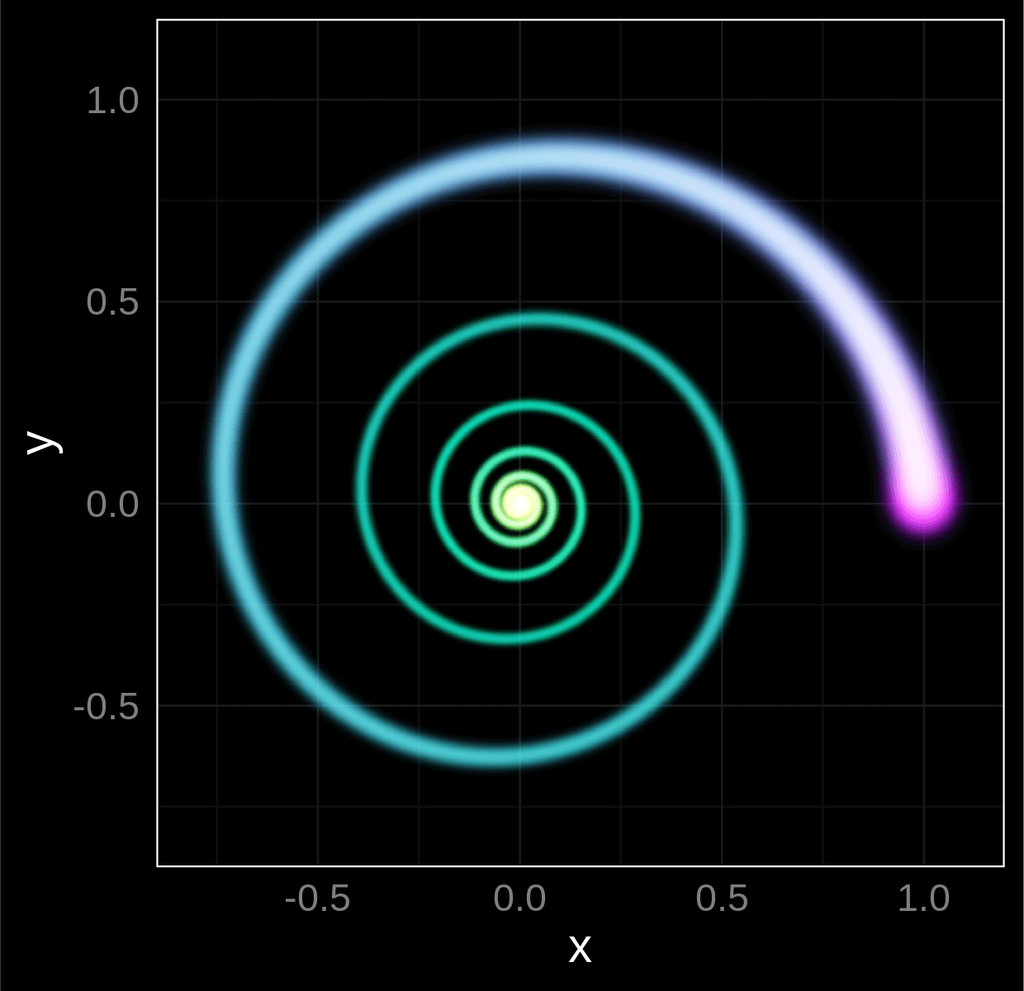

Milky Way Galaxy (6.1 million stars)

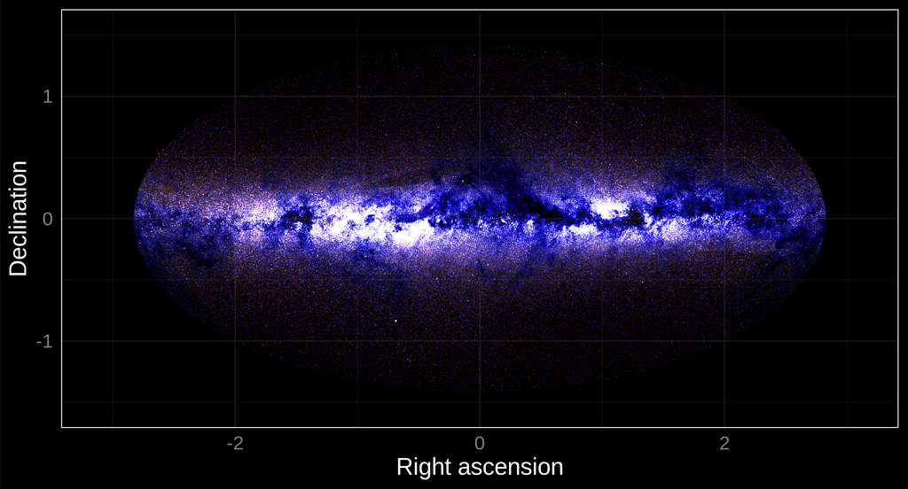

Airline Dataset (145 million points)

Methylation 450K Volcano Plot

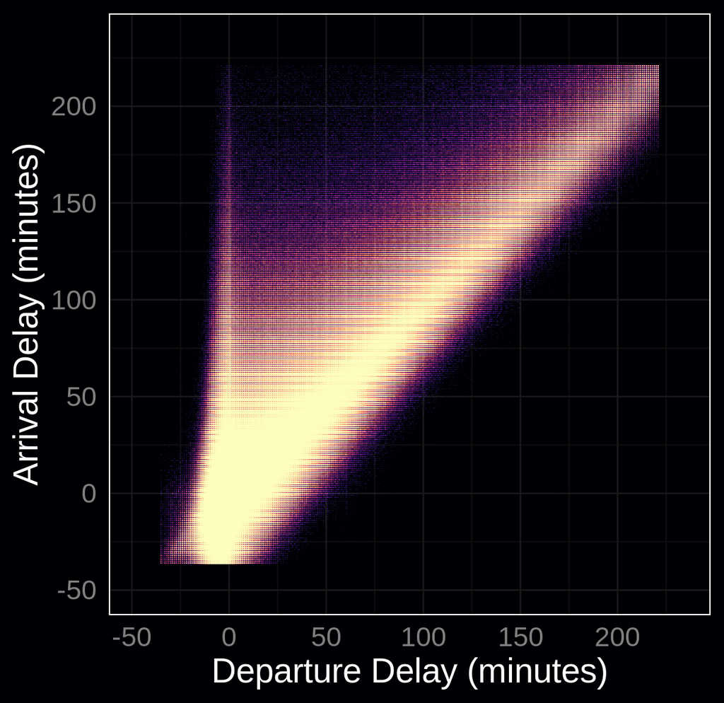

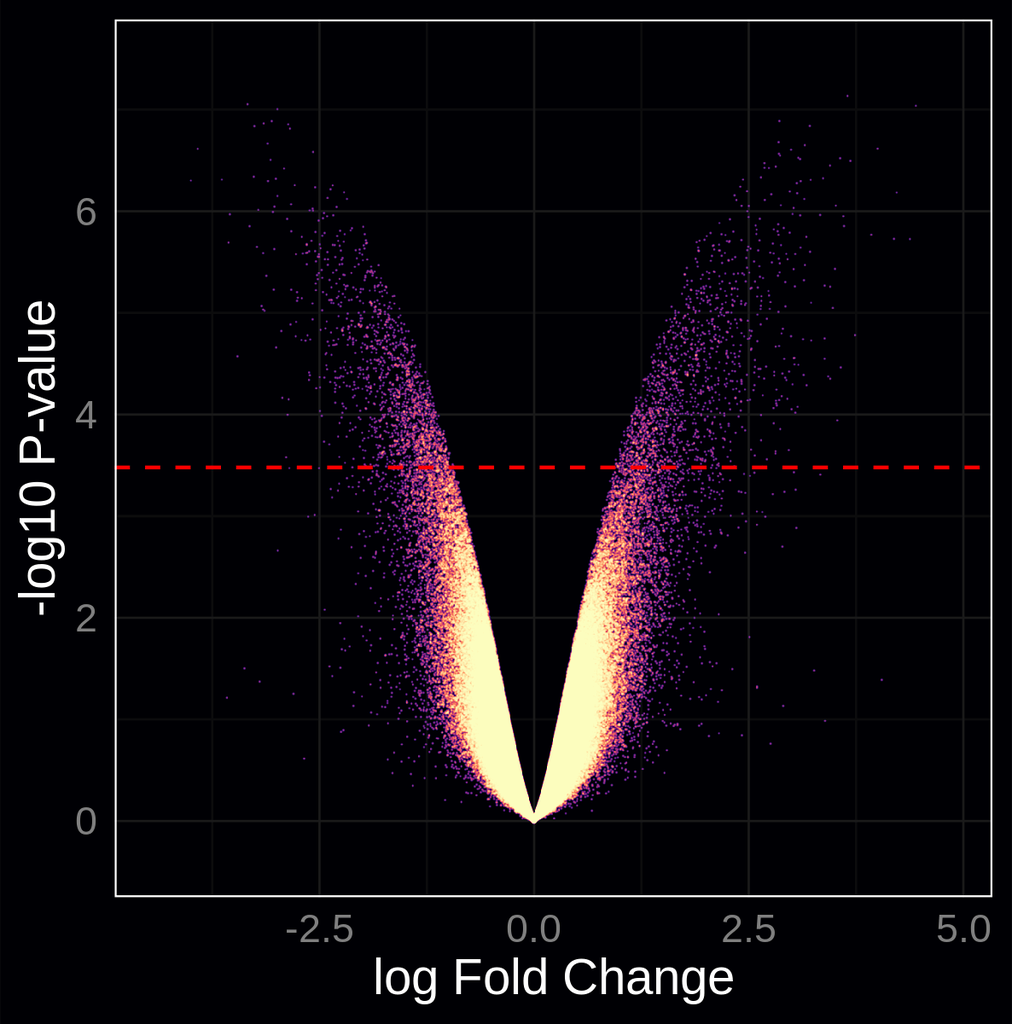

U.S. Coronavirus Cases

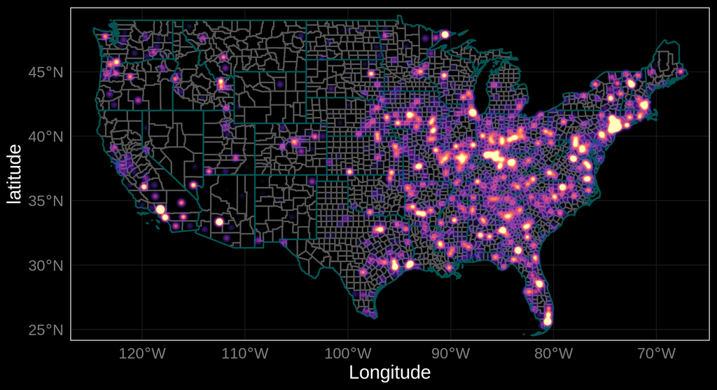

## Installation

```r
remotes::install_github("traversc/glow")
```

### Some advantages over traditional techniques

- Naturally displays point density
  - Points are added together rather than occluding earlier points in a plot
- `glow` plots don’t depend on the order of points in the data (points are commutative and associative)
  - Plotting a red point over a green point is the same as a green point over a red point
- Very fast, can be faster than `geom_point` depending on settings
- Multi-threaded
- No loss of precision and individual point coordinates compared to binning procedures
- Naturally works with larger-than-memory datasets (See “Airline” dataset in `tests/examples.r`)

## Usage

Creating a glow plot is done through the `GlowMapper` or `GlowMapper4` classes, which utilize the `R6` class framework.

The class function `$map` creates a raster that can be plotted with `ggplot`’s `geom_raster`.

See the help files and `tests/examples.r` for more information and examples.

```r
library(glow)
library(ggplot2)
library(viridisLite) # Magma color scale

# Load the dataset
data(diamonds)
gm <- GlowMapper$new(xdim=2000, ydim = 2000, blend_mode = "screen", nthreads=nt)
gm$map(x=diamonds$carat, y=diamonds$price, intensity=1, radius = .1)
pd <- gm$output_dataframe(saturation = 1)
ggplot() +
  geom_raster(data = pd, aes(x = pd$x, y = pd$y, fill = pd$value), show.legend = F) +
  scale_fill_gradientn(colors = additive_alpha(magma(12))) +
  coord_fixed(gm$aspect(), xlim = gm$xlim(), ylim = gm$ylim()) +
  labs(x = "carat", y = "price") +
  theme_night(bgcolor = magma(1))
```